# Actividad de experimentos aleatorios

```r
library(stringi)
library(dplyr)
```

# Experimentos sencillos

Primero estableceremos algunas herramientas sencillas para llevar a cabo experimentos aleatorizados.

En el fondo estamos usando la función `sample` con parámetros pre-especificados.

El lector interesado sabrá como utilizar esta función para escribir sus propios simuladores y ampliar su repertorio de herramientas.

Una moneda justa.

```r
rMoneda <- function(){
  return(sample(c("Cara", "Sello"), 1))
}
```

Un dado justo.

```r
rDado <- function(){
  return(sample(6, 1))
}
```

Una mano de `k` cartas, extraídas sin reemplazo y sin orden de un mazo bien mezclado.

El valor por defecto de `k` es 5, las cartas salen en el orden de extracción, pero en general se considera que las manos no tienen orden.

Esto se deja sin especificar para versatilidad de la herramienta.

```r
rMano <- function(k = 5){
  Ran <- rep(c("A", 2: 10, "J", "Q", "K"),4)
  Pin <- c(rep("♠", 13), rep("♦", 13), rep("♣", 13), rep("♥", 13))
  Mazo <- paste(Ran, Pin, sep = "")
  return(sample(Mazo, k))
}
```

Una colección de `k` objetos extraídos con o sin reemplazo (dependiendo del parámetro `reemplazo`) y con o sin orden (dependiendo del parámetro `orden`).

Los objetos se especifican mediante el parámetro `Objetos` y sus cantidades se especifican mediante el parámetro `Cantidades`.

Los objetos se manejan como objetos distinguibles desde el punto de vista físico (para efectos de la extracción), pero se pueden manejar de manera indistinguible de manera lógica.

```r
rCosas <- function(k, Objetos, Cantidades, reemplazo = FALSE, orden = FALSE){
  Bolsa <- rep(Objetos,Cantidades)
  X <- sample(Bolsa, k, replace = reemplazo)
  if(!orden){
    return(paste(sort(X), collapse = ""))
  }
  else{
    return(paste(X, collapse = ""))
  }
}
```

```r
rCosas(4, c("R", "V", "A"), c(4,3,3), reemplazo = FALSE, orden = TRUE)
```

```
[1] "RRAV"
```

# Réplicas independientes

Para estudiar los distintos experimentos desde el punto de vista práctico, se puede utilizar la función `replicate`.

Recuerden que si necesitan información adicional sobre el funcionamiento de un comando o función de R, pueden invocar la ayuda de R usando `?`.

Por ejemplo, para saber como funciona `replicate` basta con ejecutar `? replicate`.

Es importante entender que la función `replicate` también se puede utilizar para crear experimentos más complejos.

Por ejemplo, si quisiéramos estudiar 30 lanzamientos de un dado justo podemos hacer:

```r
replicate(30, rDado())
```

Evidentemente, para estudiar los resultados desde el punto de vista estadístico, habría que guardar los resultados en una variable para poder procesarlos con cuidado.

Por ejemplo, podemos guardar 10 resultados en un vector `X` y luego estudiarlo desde el punto de vista estadístico.

```r
X <- replicate(10, rDado())
```

```r
table(X)
```

```r
barplot(table(X))
```

*Claramente* 10 réplicas independientes podrían no ser suficientes para explorar completamente el espacio de resultados.

Una manera *empírica* de estudiar el espacio de resultados se puede lograr usando la función `unique`.

```r
unique(X)
```

Sabemos que desde el punto de vista teórico, el espacio de resultados de un dado justo es equiprobable y consiste de los números del 1 al 6.

$\Omega = \{1, 2, 3, 4, 5, 6 \}$

Un experimento interesante podría ser:

## E1

Lanzamos un dado justo 10 veces y anotamos si salieron todos los resultados posibles del dado.

Este experimento tiene solo dos resultados posibles “Si” y “No”, que representaremos mediante los valores `TRUE` y `FALSE`, es decir $\Omega_1 = \{TRUE ,FALSE\}$.

En esencia, el experimento es simplemente considerar la siguiente evaluación una cierta cantidad de veces.

```r
length(unique(replicate(10, rDado()))) == 6
```

Como se vuelve engorroso escribir la expresión anterior muchas veces, es conveniente encapsularla en una función, de manera similar a como hicimos con la función `sample` para escribir `rMoneda`, `rDado`, `rMano` y el resto de las funciones.

```r
rE1 <- function(){
  return(length(unique(replicate(10, rDado()))) == 6)
}
```

Podemos considerar que ocurre cuando hacemos 100 replicas independientes del experimento E1.

```r
X1a <- replicate(100, rE1())
```

y en función de estos resultados podemos estimar empíricamente las probabilidades de los dos resultados posibles de E1.

```r
table(X1a)/length(X1a)
```

y si repitiésemos el experimento, casi con toda certeza, los resultados serían diferentes y los estimados empíricos de la probabilidad también cambiarían.

```r
X1b <- replicate(100, rE1())
table(X1b)/length(X1b)
```

La función `jitter` puede ser útil para la visualización, pues agrega una pequeña cantidad aleatoria a cada valor para evitar que las observaciones caigan una encima de la otra y parezcan menos de las que son.

En R, los valores `TRUE` y `FALSE` son valores lógicos, pero se pueden convertir fácilmente a valores numéricos de manera automática; en el siguiente ejemplo logramos eso sumando 0 a cada valor.

```r
plot(X1a, X1b)
```

```r
plot(jitter(X1a+0), jitter(X1b+0))
```

Finalmente, determinar la probabilidad correcta para cada resultado de E1, desde el punto de vista teórico, puede ser complicado, pues requiere de conocimientos de conteo.

Desde el punto de vista teórico, la probabilidad `p` de ver todos los resultados posibles de un dado justo en 10 lanzamientos se calcula usando conteo y el principio de inclusión-exclusión.

```r
p <- sum(choose(6,6:1)*((6:1)^10)*((-1)^(6:1)))/6^10
```

Al contar con una herramienta como `rE1` simplemente podemos hacer *suficientes* réplicas y estimar dichas probabilidades.

```r
X1 <- replicate(1000, rE1())
```

```r
table(X1)/length(X1)
```

```r
B <- barplot(table(X1) / length(X1), ylim = c(0 ,1))
points(B,c(1-p, p), pch = 19)
```

Al final del curso entenderemos que *grande* o *pequeño* en estadística tiene un significado flexible y que realmente depende del contexto.

¿Qué retorna la función `barplot`?

Para construir experimentos más complicados usando `replicate` y otras funciones de R, simplemente hay que pensar cual es el experimento que se desea estudiar.

Por ejemplo, podemos estudiar la suma de tres dados justos.

## E2

Definiremos de un vez una función para generar nuestros resultados

```r
rE2 <- function(){
  return(sum(replicate(3, rDado())))
}
```

Claramente $\Omega_2 = \{ 3,4,5,6,7,8,9,10,11,12,13,14,15,16,17,18\}$ y el espacio no es equiprobable.

Veamos como se ven 1000 réplicas de E2.

```r
X2a <- replicate(1000, rE2())
barplot(table(X2a))
```

Al ser la suma de tres dados justos una variable numérica discreta, podemos analizarla desde el punto de vista estadístico de la manera habitual.

```r
summary(X2a)
```

```r
boxplot(X2a)
```

```r
hist(X2a, breaks = (3:19) - 0.5, col = "lightgreen")
```

Recuerden que hasta el conjunto base de R para hacer gráficas es bastante sofisticado y uno puede hacer gráficas muy descriptivas con herramientas relativamente sencillas.

```r
hist(X2a
     , breaks = (3:19) - 0.5
     , col = "lightgreen"
     , prob = TRUE
     , ylim = c(-0.08, 0.3)
     , main = "Suma de tres dados justos"
     , sub = paste("Muestra de", length(X2a), "experimentos")
     , ylab = "probabilidad empírica"
     , xlab = "valor"
     )
boxplot(X2a, horizontal = TRUE, add = TRUE, at = -0.05, boxwex = 0.05, col = "lightgreen")
```

## E3

Consideremos el experimento extraemos dos cartas en orden de un mazo bien mezclado.

Un resultado de este experimento es:

```r
rMano(2)
```

Este experimento es equiprobable y su número de resultados posibles es variaciones de 52 en 2 $V^{52}_2=\frac{52!}{(52-2)!}=\binom{52}{2}2!$.

Si quisiéramos saber cual es la probabilidad de que ambas cartas fuesen reyes, desde el punto de vista teórico, la respuesta sería $\mathbb{P}(\text{ambas cartas son reyes}) = \frac{V^4_2}{V^{52}_2}=\frac{1}{221}$.

Si quisiéramos estudiar la probabilidad calculada mediante un experimento, podemos pensar en el siguiente experimento accesorio.

Replicamos el experimento E3 un número elevado de veces, por ejemplo 1000 veces y guardamos los resultados.

Procesamos los resultados para adecuarlos al experimento que queremos estudiar.

```r
X3a <- replicate(1000, rMano(2), simplify = FALSE)
```

Ahora `X3a` es una lista de 1000 entradas correspondientes a las distintas réplicas de nuestro experimento, cada réplica consiste de una lista con dos cartas diferentes.

Si quisiéramos el resultado de la primera replica podríamos acceder a esta mediante `X3a[[1]]`.

Hay una diferencia sutil entre usar `[]` y usar `[[]]`.

En el primer caso se enfatiza que el resultado es una sub-lista de la lista original (aunque tenga un solo elemento), mientras que en el segundo el resultado es un elemento de la lista original.

Lista de largo 1.

```r
X3a[1]
```

Primer elemento de la lista `x3a` (que es un vector de largo 2).

```r
X3a[[1]]
```

Al igual que con los *data frames*, las funciones `head` y `tail` pueden servir para ver los primeros o últimos componentes de una lista.

```r
head(X3a)
```

Tener los resultados de `X3a` en una tabla puede ser conveniente para manipularlos.

Para esto necesitamos un par de funciones:

```r
priCarta <- function(M){
  return(M[1])
}
```

```r
segCarta <- function(M){
  return(M[2])
}
```

```r
PrimeraCarta <- Vectorize(priCarta)
```

```r
SegundaCarta <- Vectorize(segCarta)
```

```r
TablaX3a <- data.frame(
  Primera = PrimeraCarta(X3a)
  , Segunda = SegundaCarta(X3a)
  , stringsAsFactors = FALSE
  )
```

Podemos revisar que nuestros datos siguen allí comparando `X3a` y `TablaX3a`.

```r
head(X3a)
```

```r
head(TablaX3a)
```

```r
head(TablaX3a$Primera)
```

```r
head(TablaX3a$Segunda)
```

Finalmente, podemos determinar si ambas cartas son reyes de la siguiente manera.

```r
Rango <- function(M){
  stri_sub(M, from = 1, to = 1)
}
```

```r
TablaX3a$RangoPrimera <- Rango(TablaX3a$Primera)
TablaX3a$RangoSegunda <- Rango(TablaX3a$Segunda)
```

```r
head(TablaX3a)
```

```r
TablaX3a$AmbasSonReyes <- (TablaX3a$RangoPrimera == "K") & (TablaX3a$RangoSegunda == "K")
```

Finalmente, podemos estimar, para la muestra obtenida, la probabilidad de que ambas cartas sean reyes.

```r
sum(TablaX3a$AmbasSonReyes)/nrow(TablaX3a)
```

Dos cosas deberían ser evidentes en este punto:

- Nuestro estimado podría ser malo ya que el evento *Ambas cartas son reyes* parece ser relativamente raro (sabemos cuán raro pues calculamos su probabilidad, por lo que en realidad no necesitamos estimarla).
- Hicimos un montón de trabajo para responder una pregunta cuya respuesta ya conocíamos.

Lo interesante es que para responder la pregunta no usamos *nunca* la probabilidad teórica, por lo que si pudiésemos resolver la primera observación, deberíamos poder usar este tipo de enfoque para atacar otros problemas donde en realidad no conocemos la probabilidad teórica.

Veamos una segunda muestra con muchas más réplicas y sin tanta conversación:

```r
X3b <- replicate(100000, rMano(2), simplify = FALSE)

TablaX3b <- data.frame(
  Primera = PrimeraCarta(X3b)
  , Segunda = SegundaCarta(X3b)
  , stringsAsFactors = FALSE
  )

TablaX3b$RangoPrimera <- Rango(TablaX3b$Primera)
TablaX3b$RangoSegunda <- Rango(TablaX3b$Segunda)

TablaX3b$AmbasSonReyes <- (TablaX3b$RangoPrimera == "K") & (TablaX3b$RangoSegunda == "K")
```

La probabilidad estimada ahora es:

```r
qest <- sum(TablaX3b$AmbasSonReyes)/nrow(TablaX3b)
qest
```

Y el error absoluto del estimado respecto a la probabilidad teórica es de:

```r
abs(qest - 1/221)
```

mientras que el error relativo es de:

```r
abs(qest - 1/221)/(1/221)
```

Todas estas cosas se hacen naturales con la práctica y alguien con un poco de experiencia, interés y perseverancia puede responder preguntas verdaderamente complejas con experimentos muy sencillos.

## E4

Por ejemplo, si quisiésemos saber cual es la probabilidad de que ninguna de las dos cartas sea un rey o una reina, podemos hacer los siguiente.

```r
niReyniReina <- function(Rangos){
  return(!any((Rangos == "K") | (Rangos == "Q")))
}
```

```r
niReyniReina(Rango(rMano(2)))
```

```r
X4a <- replicate(1000, niReyniReina(Rango(rMano(2))))
```

```r
table(X4a)/length(X4a)
```

# Ejercicios…

Una bolsa con 10 bolas, 4 rojas, 3 verdes, 3 azules Sacamos 4 bolas, una a la ve, sin reemplazo, SÍ importa el orden

```r
rE5 <- function(){
  return(rCosas(4, c("R", "V", "A"),c(4,3,3), reemplazo = FALSE, orden=TRUE))
}
```

```r
rE5()
```

```
[1] "AVAR"
```

```r
X5a <- replicate(10000, rE5())
```

```r
length(unique(X5a))
```

```
[1] 79
```

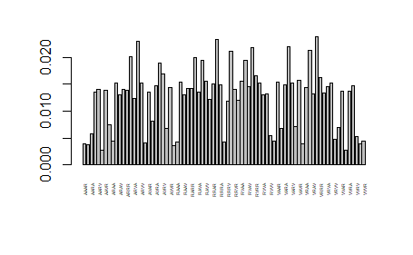

```r
barplot(table(X5a)/length(X5a), las=3, cex.names = 0.3)
```

Una bolsa con 10 bolas, 4 rojas, 3 verdes, 3 azules Sacamos 4 bolas, una a la ve, sin reemplazo, NO importa el orden

```r
rE6 <- function(){
  return(rCosas(4, c("R", "V", "A"),c(4,3,3), reemplazo = FALSE, orden=FALSE))
}
```

```r
X6a <- replicate(1000, rE6())
```

```r
length(unique(X6a))
```

```
[1] 13
```